# Frequentist A/B test

> [Source code](https://github.com/ethen8181/Business-Analytics/blob/master/ab_tests/frequentist_ab_test.R) to follow along the documentation.

# Getting Started

## Hypothesis Testing

In order to understand classic frequentist A/B testing, you have to understand the basics of frequentist hypothesis testing. We’ll use a classic “intervention” example found in most industries as a motivation. Let’s say we want to conduct an experiment to test if a certain action helps prevent the occurrence of an adverse event. Depending on the business, this event could be fraud, attrition, downgrades, account closure, etc. The goal is to contact just enough people to decide if the action should be launched at full scale.

**Step 1 - Create a null hypothesis and an alternative hypothesis**

- Null hypothesis $(H_0)$: the event rates are the same for the test/experiment and control groups.
- Alternative hypothesis $(H_1)$: the event rates are different

Note that the event rate refers to the proportion of clients for whom the event is observed (e.g., fraud, attrition, downgrades, etc.).

The null hypothesis is the hypothesis of no impact, while the alternative hypothesis is that the action will have an impact. To be explicit, this is a two-sided hypothesis, since we are testing if the event rate improved or worsened.

**Step 2 - Draw a sample**

Let’s say we draw a sample of N clients where 50% are exposed to the action and 50% are not. Note that the split is random, but does not have to be exactly 50/50. We’ll learn how to choose N later.

**Step 3 - Calculate the test statistic**

Select the appropriate test statistic and calculate its value from the data (we will call it Z). A test statistic is a single metric that can be used to evaluate the null hypothesis. For our test the underlying metric is a binary yes/no variable (event), which means that the appropriate test statistic is a test for differences in proportions. Math formula:

$$Z = \frac{ p_{experiment} - p_{control} }
{ \sqrt{ p_{pooled}( 1-p_{pooled} )( \frac{1}{n_{experiment}} + \frac{1}{n_{control}}) } }$$

Where:

- $p_{control}$ and $p_{experiment}$ are the event rates for the control and experiment groups, respectively.
- $n_{control}$ and $n_{experiment}$ are the sample sizes for the control and experiment groups, respectively.
- $p_{pooled}$ is the blended rate: $( x_{control} + x_{experiment} ) \big/ ( n_{control} + n_{experiment} )$ where $x_{control}$ and $x_{experiment}$ are event counts for the control and experiment groups, respectively.

For testing of continuous variables, such as revenue, see the appendix of this post.

**Step 4 - Reject or accept the null hypothesis**

Based on the test statistic we can calculate the **p-value** which is probability of obtaining a result at least as “extreme” as the observed result by random chance, given that the null hypothesis is true. It is tempting to interpret the **p-value** as the probability of rejecting the null hypothesis when it is true, but technically speaking that is an incorrect interpretation, in fact this is what’s called the Type I error (detail later).

Here’s an concrete example, suppose that a vaccine study produced a **p-value** of 0.04. This **p-value** indicates that if the vaccine had no effect, you’d obtain the observed difference or more in 4% of studies due to random sampling error. **p-value** address only one question: how likely are your data, assuming a true null hypothesis? It does not measure support for the alternative hypothesis!!!! Thus, while a low **p-value** indicates that your data are unlikely assuming a true null hypothesis, it can’t evaluate which of two competing cases is more likely:

- The null is true but your sample was unusual.
- The null is false.

Determining which case is more likely requires subject area knowledge and replicate studies.

If we seek to reject the null hypothesis, we want the **p-value** to be small and the typical threshold used is 5%. In other words, if the **p-value** is less than 5%, and the test group experienced a lower event rate than the control group, we conclude that the action worked. In other words, we are reasonably sure that there is something besides chance alone that gave us the observed data. The pre-chosen cutoff (5%) is also referred to as the **significance level** and plays an important role in determining the required sample size (detail later).

Note that we do not have to directly calculate the p-value in order to reject or accept the null hypothesis. Alternatively, we can apply a cutoff directly to the test statistic (Z) based on its distribution and the chosen significance level. For example, for a two-sided test and a significance level of 5%, the cutoff corresponds to the upper and lower 2.5% on the standard normal distribution (normal distribution with a mean of 0 and a standard deviation of 1), which is 1.96. Hence we reject the null hypothesis if $\lvert Z \rvert > 1.96$.

**Introducing the Power and the Significance Level**

In the world of hypothesis testing, rejecting the null hypothesis when it is actually true is called a type 1 error. Committing a type 1 error is a false positive because we end up recommending something that does not work.

Conversely, a type 2 error occurs when you accept the null hypothesis when it is actually false. This is a false negative because we end up sitting on our hands when we should have taken action. We need to consider both of these types of errors when choosing the sample size.

Two important probabilities related to type 1 and type 2 error are:

| Scenario | $H_0$ is true | $H_0$ is false |
| --- | --- | --- |
| Accept $H_0$ | Correct Decision | Type 2 Error (1 - power) |
| Reject $H_0$ | Type 1 Error (significance level) | Correct decision |

The concepts of power and significance level can seem somewhat convoluted at first glance. A good way to get a feel for the underlying mechanics is to plot the probability distribution of Z assuming that the null hypothesis is true. Then do the same assuming that the alternative hypothesis is true, and overlay the two plots.

Consider the following example:

- $H_0: p1 = p2$, $H_1: p 1> p2$. A one-sided test was chosen here for charting-simplicity. Our chosen significance level is 5%. The corresponding decision rule is $\lvert Z \rvert > 1.65$. The number (1.65) is the cutoff that corresponds to the upper 5% on the standard normal distribution.
- Total sample size, N=5,000 (assume equal sample sizes for the control and experiment groups, meaning exactly 2,500 in each group).
- Say we decide that we need to observe a difference of 0.02 (detailed later) in order to be satisfied that the intervention worked (i.e., $p_1 = 0.10$ and $p_2 = 0.08$). We will discuss how to make this decision later in the post. The desired difference of 0.02 under the alternative hypothesis corresponds to $Z = 2.47$ (using the formula for Z above). If you wish to convert the Z-score that is found to **p-value**, you can do it by one minus the associated probability. Also, for a two sided test we need to multiply the result by two. `2 * ( 1- pnorm( abs(Z) ) )`.

```r
library(scales)
library(ggplot2)
library(data.table)

plot_power <- function(size, min_diff) {

    size_a <- size_b <- size * 0.5 # size are assumed to be equal
    p_a <- 0.08 # baseline
    p_b <- p_a + min_diff
    count_a  <- size_a * p_a
    count_b  <- size_b * p_b
    p_pooled <- (count_a  + count_b) / (size_a + size_b)
    Z <- (p_b - p_a) / sqrt( p_pooled * (1 - p_pooled) * (1 / size_a + 1 / size_b) )

    # Z corresponds to the mean of the normal distribution
    mean1 <- 0
    mean2 <- Z

    x <- seq(-4, 6, 0.1) # use for generating the x axis of the normal distribution
    data <- data.frame( x = x, y1 = dnorm(x, mean1, 1), y2 = dnorm(x, mean2, 1) )

    plot <- ggplot( data, aes(x = x) ) +
            geom_line( aes( y = y1, colour = 'H0 is true' ), size = 1.2 ) +
            geom_line( aes( y = y2, colour = 'H1 is true' ), size = 1.2 ) +
            geom_area( aes( y = y1, x = ifelse(x > 1.65, x, NA) ), fill = 'black' ) +
            geom_area( aes( y = y2, x = ifelse(x > 1.65, x, NA) ), fill = 'blue', alpha = 0.3 ) +
            labs( x = '', y = '', title = sprintf('p1 = %s, p2 = %s, size = %d', p_a, p_b, size) ) +
            theme( legend.title = element_blank() ) +
            scale_colour_manual( breaks = c("H0 is true", "H1 is true"),
                                 values = c("blue", "red") )
    return(plot)
}
```

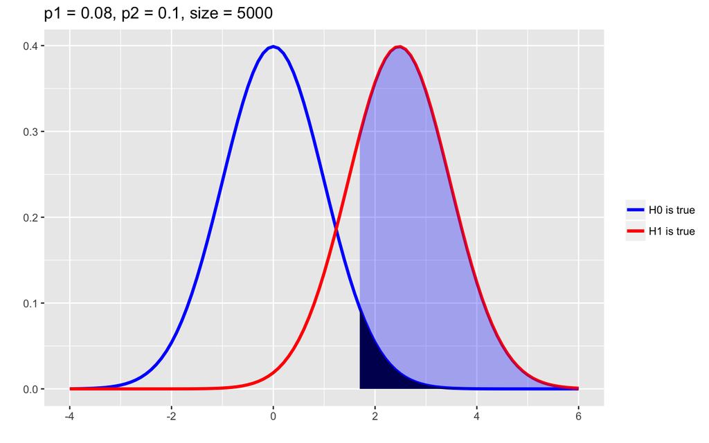

```r
plot_power(size = 5000, min_diff = 0.02)
```

The shaded dark blue area denotes the significance region, while the the shaded blue area denotes the power (note that it includes the shaded dark blue area). Note that if we pick a smaller N, or a smaller probability difference between the control and experiment group, the power drops (the shaded blue area decreases), meaning that if there’s is in fact a change, there’s lesser percent chance that we’ll detect it:

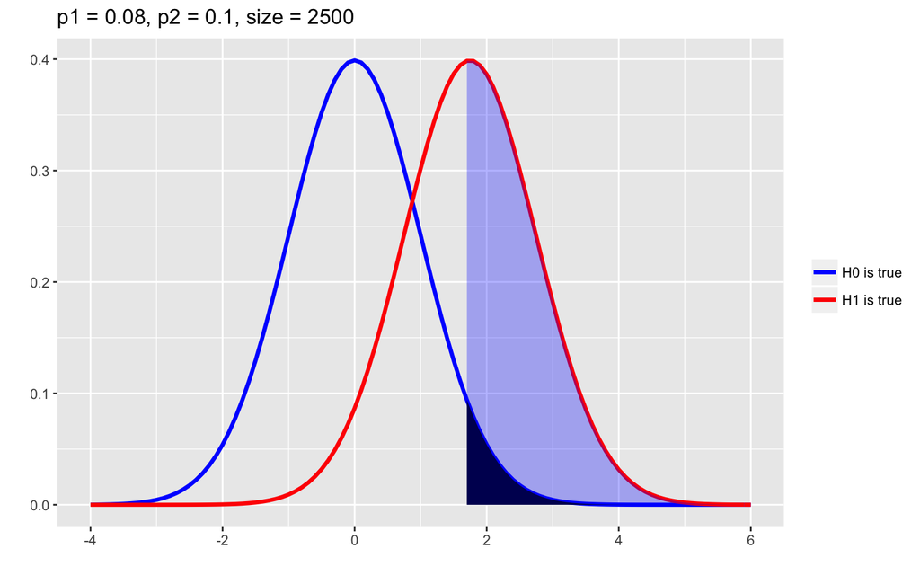

```r
# smaller N
plot_power(size = 2500, min_diff = 0.02)
```

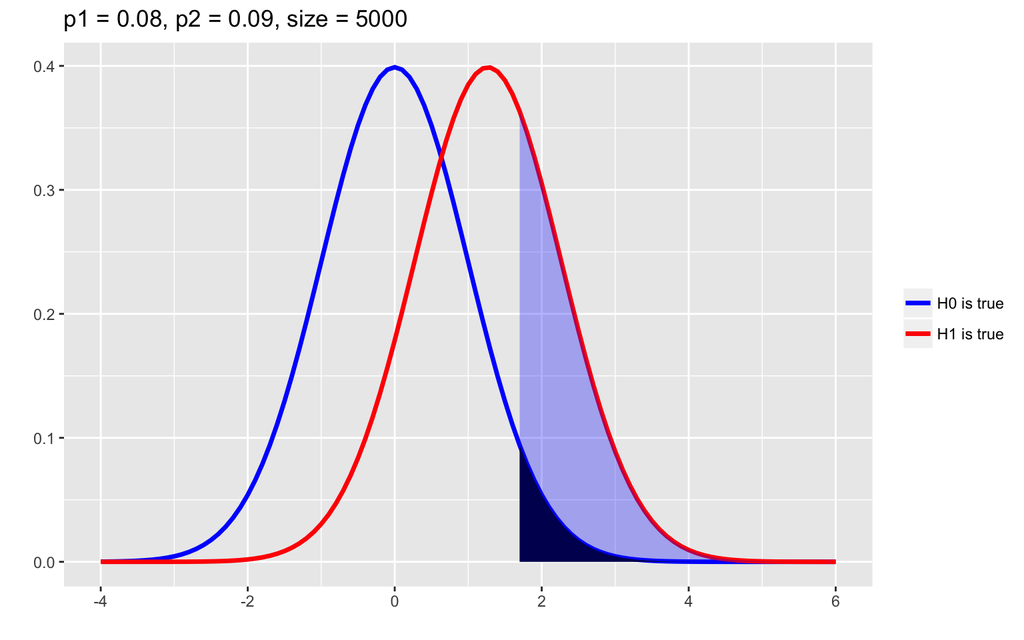

```r
# smaller probability difference
plot_power(size = 5000, min_diff = 0.01)
```